# Cauchy MLE using Simulated Annealing: Complete Code Explanation

Sulagna Roy

2026-09-12

# Introduction

This document provides a comprehensive explanation of R code that implements **Simulated Annealing** to find the Maximum Likelihood Estimate (MLE) of the location parameter μ for a Cauchy distribution.

**Key Challenge:** The log-likelihood for Cauchy distribution is **multimodal (non-concave)**, making standard optimization methods fail. Simulated Annealing overcomes this by using temperature-dependent probabilistic moves.

# Part 1: Initialization and Data Generation

## Code Explanation

```r
set.seed(1)           # Set seed for reproducibility
mu.star <- 5          # True location parameter
n <- 4                # Sample size
X <- rt(n, df = 1) + mu.star
```

## Detailed Explanation

- **`set.seed(1)`**: Ensures reproducible random number generation
- **`mu.star <- 5`**: The true location parameter (what we’re trying to estimate)
- **`n <- 4`**: Sample size
- **`rt(n, df = 1)`**: Generates n=4 samples from Student’s t-distribution with 1 degree of freedom
  - This is equivalent to the **Cauchy distribution**
  - A heavy-tailed distribution with undefined mean and variance
- **`X <- rt(n, df = 1) + mu.star`**: Shifts the Cauchy samples by adding μ*=5
  - Result: X_i = Z_i + 5, where Z_i ~ Cauchy(0,1)
  - Final data: X ~ Cauchy(μ=5)

## Purpose

This creates sample data from a known distribution so we can: 1. Test whether the algorithm recovers the true parameter (μ*=5) 2. Visualize the likelihood function 3. Demonstrate algorithm convergence

# Part 2: Log-Likelihood Function

## Code

```r
log.like <- function(mu, X, T = 1)
{
  n <- length(X)
  rtn <- -n*log(pi) - sum( log(1 + (X - mu)^2) )
  return(exp(rtn/T))
}
```

## Mathematical Background

The log-likelihood for Cauchy distribution is:

$$\ell(\mu) = -n \ln(\pi) - \sum_{i=1}^{n}
\ln(1 + (X_i - \mu)^2)$$

## Code Explanation

- **Input Parameters:**
  - `mu`: Location parameter (what we’re optimizing)
  - `X`: Observed data
  - `T`: Temperature (default = 1)
- **`n <- length(X)`**: Gets sample size
- **`rtn <- -n*log(pi) - sum(log(1 + (X - mu)^2))`**:
  - Calculates the log-likelihood
  - `-n*log(pi)`: First term (constant across μ values)
  - `sum(log(1 + (X - mu)^2))`: Sum of log terms
- **`return(exp(rtn/T))`**:
  - Returns **transformed likelihood** = exp(ℓ(μ)/T)
  - NOT the standard likelihood

## Why exp(ℓ/T)?

This is the key innovation for optimization:

**Temperature Effect on Landscape:**

- **High T (e.g., T=1):**
  - exp(ℓ/T) ≈ 1 + ℓ/T
  - Function is smooth and nearly flat
  - Differences between peaks are dampened
  - Algorithm explores broadly (exploitation minimized)
- **Low T (e.g., T=0.1):**
  - exp(ℓ/T) amplifies peaks
  - Sharp, pronounced peaks
  - Differences between solutions are magnified
  - Algorithm refines locally (exploration reduced)

**This creates the exploration → exploitation transition!**

# Part 3: Likelihood Visualization

## Code

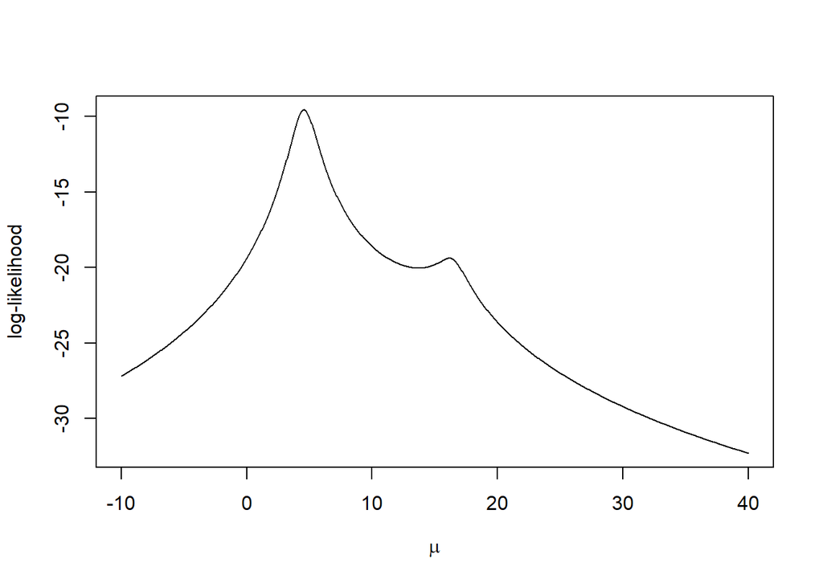

```r
mu.x <- seq(-10, 40, length = 1e3)  # 1000 values from -10 to 40
ll.est <- log(sapply(mu.x, log.like, X))  # Evaluate log-likelihood
plot(mu.x, ll.est, type = 'l',
     ylab = "log-likelihood",
     xlab = expression(mu))
```

## Step-by-Step Explanation

### Step 1: Create Parameter Grid

```r
mu.x <- seq(-10, 40, length = 1e3)
```

- Creates 1000 equally-spaced values from -10 to 40
- These represent candidate parameter values

### Step 2: Evaluate Likelihood at Each Point

```r
ll.est <- log(sapply(mu.x, log.like, X))
```

- **`sapply(mu.x, log.like, X)`**:
  - Apply function `log.like` to each value in `mu.x`
  - Returns a vector of transformed likelihoods (with T=1)
- **`log(...)`**:
  - Takes natural logarithm
  - Converts exp(ℓ/T) back to ℓ scale for visualization
  - Makes it easier to see the shape

### Step 3: Visualize

```r
plot(mu.x, ll.est, type = 'l', ylab = "log-likelihood", xlab = expression(mu))
```

- Creates line plot of log-likelihood vs. μ
- Shows the **multimodal structure**

## Key Observation

The log-likelihood has **multiple peaks** (local maxima), which is why: - **Gradient-based methods fail**: They get trapped in nearest local peak - **Simulated Annealing is needed**: To jump between peaks and find global maximum

# Part 4: Simulated Annealing Algorithm

This is the core algorithm. We’ll break it into parts.

## Complete Algorithm

```r
simAn <- function(N = 10, r = .5){
  # ========== INITIALIZATION ==========
  x <- numeric(length = N)                    # Store parameter trajectory
  x[1] <- runif(1, min = -10, max = 40)     # Random starting point
  fn.value <- numeric(length = N)            # Store likelihood values

  fn.value[1] <- log.like(mu = x[1], X, T = 1)

  # ========== MAIN LOOP ==========
  for(k in 2:N){

    # STEP 1: Generate Candidate (Random Walk)
    a <- runif(1, x[k-1] - r, x[k-1] + r)

    # STEP 2: Temperature Schedule (Cooling)
    T <- 1/(1 + log(log(k)))

    # STEP 3: Acceptance Ratio (Metropolis)
    ratio <- log.like(mu = a, X, T)/log.like(mu = x[k-1], X, T)

    # STEP 4: Accept or Reject (Metropolis Criterion)
    if( runif(1) < ratio){
      x[k] <- a
    } else{
      x[k] <- x[k-1]
    }

    # Store function value at T=1 (for comparison)
    fn.value[k] <- log.like(mu = x[k], X, T = 1)
  }

  # Return both trajectory and function values
  return(list("x" = x, "fn.value" = fn.value))
}
```

## Detailed Explanation

### Initialization Phase

```r
x <- numeric(length = N)
x[1] <- runif(1, min = -10, max = 40)
fn.value <- numeric(length = N)
fn.value[1] <- log.like(mu = x[1], X, T = 1)
```

- **`x <- numeric(length = N)`**:
  - Vector to store all N parameter values (the algorithm’s trajectory)
- **`x[1] <- runif(1, min = -10, max = 40)`**:
  - Initialize with random value in [-10, 40]
  - Ensures we don’t start at a known optimum
  - Allows multiple runs to explore different regions
- **`fn.value`**:
  - Stores likelihood values
  - Always evaluated at T=1 for comparability

### Main Loop: Step 1 - Candidate Generation

```r
a <- runif(1, x[k-1] - r, x[k-1] + r)
```

**What it does:** - Generates a candidate solution `a` - From uniform distribution centered at current position x_{k-1} - Range: [x_{k-1} - r, x_{k-1} + r]

**Parameters:** - **r = 0.5** (default): Step size/neighborhood radius - r=0.5 means candidate is within ±0.5 of current position - Larger r: Bigger jumps, more exploration, fewer acceptances - Smaller r: Smaller jumps, slower exploration, more acceptances

**Purpose:** Implement random walk to explore parameter space locally

### Main Loop: Step 2 - Temperature Schedule

```r
T <- 1/(1 + log(log(k)))
```

**Temperature Calculation:** - Formula: $T_k = \frac{1}{1 + \ln(\ln(k))}$ - Decreases monotonically as k increases (cooling schedule)

**Temperature Evolution:**

```r
k_values <- c(2, 5, 10, 50, 100, 500, 1000)
T_values <- 1/(1 + log(log(k_values)))
schedule_df <- data.frame(Iteration = k_values, Temperature = round(T_values, 4))
print(schedule_df)
```

```
##   Iteration Temperature
## 1         2      1.5786
## 2         5      0.6776
## 3        10      0.5452
## 4        50      0.4230
## 5       100      0.3957
## 6       500      0.3537
## 7      1000      0.3410
```

**Key Properties:** - **Early iterations** (small k): ln(ln(k)) is small → T is large - High temperature = smooth landscape - Algorithm accepts bad moves frequently - **Broad exploration of parameter space**

- **Late iterations** (large k): ln(ln(k)) is large → T is small
  - Low temperature = sharp peaks
  - Algorithm rejects bad moves frequently
  - **Local refinement around best solution**
- **Asymptotic behavior:** As k → ∞, T → 0
  - Algorithm converges (stops accepting bad moves)

### Main Loop: Step 3 - Acceptance Ratio

```r
ratio <- log.like(mu = a, X, T)/log.like(mu = x[k-1], X, T)
```

**What it does:**
$$\alpha =
\frac{\ell(a)}{\ell(x_{k-1})} = \exp\left(\frac{\ell(a) -
\ell(x_{k-1})}{T}\right)$$

**Interpretation:** - **If ℓ(a) > ℓ(x_{k-1})**: - Candidate is better (higher likelihood) - α > 1 - Will be accepted (unless u > 1, impossible)

- **If ℓ(a) < ℓ(x_{k-1})**:
  - Candidate is worse (lower likelihood)
  - α < 1
  - Accepted with probability α

**Temperature Effect:**

Suppose ℓ(a) - ℓ(x_{k-1}) = -1 (worse by 1 unit):

- High T (T=0.5): α = exp(-1/0.5) = exp(-2) ≈ 0.135 → Accept with 13.5% probability
- Low T (T=0.1): α = exp(-1/0.1) = exp(-10) ≈ 0.00005 → Accept with 0.005% probability

**Interpretation:** High temperature is more **forgiving** of bad moves (exploration), while low temperature is more **selective** (exploitation).

### Main Loop: Step 4 - Metropolis Criterion (Accept/Reject)

```r
if( runif(1) < ratio){
  x[k] <- a
} else{
  x[k] <- x[k-1]
}
```

**Algorithm:** 1. Generate u ~ Uniform(0,1) 2. **If u < α**: Accept candidate (x_k ← a) 3. **Else**: Reject candidate, keep current (x_k ← x_{k-1})

**Probabilistic Acceptance:** - Since u is uniform on [0,1], P(u < α) = α - Better solutions (α > 1): Always accepted - Worse solutions (α ≤ 1): Accepted with probability α

**Why This Works:**

The key insight is that **accepting some bad moves allows escape from local maxima**:

```
START at local maximum → Temperature is high → Accept bad move anyway
       ↓
Move to different region → Climb different peak
       ↓
Temperature decreases → Stop accepting bad moves
       ↓
Converge to global maximum (if lucky) or local maximum (if unlucky)
```

### Store Function Value

```r
fn.value[k] <- log.like(mu = x[k], X, T = 1)
```

- Always evaluates at **T=1** (not temperature-adjusted)
- This is the true likelihood (not the transformed version)
- Allows fair comparison across all iterations
- Used later for finding the best solution

### Return Statement

```r
return(list("x" = x, "fn.value" = fn.value))
```

Returns a list with: - **x**: All parameter values sampled (the trajectory) - **fn.value**: Corresponding likelihood values

# Part 5: Testing the Algorithm

## Run Single Algorithm

```r
# Run simulated annealing for 100 iterations with r=5
sim <- simAn(N = 1e2, r = 5)

# Find the parameter value with highest likelihood
mu_hat <- sim$x[which.max(sim$fn.value)]
cat("Estimated MLE: mu_hat =", round(mu_hat, 4), "\n")
```

```
## Estimated MLE: mu_hat = 4.5465
```

```r
cat("True parameter: mu* =", mu.star, "\n")
```

```
## True parameter: mu* = 5
```

## Multiple Independent Runs

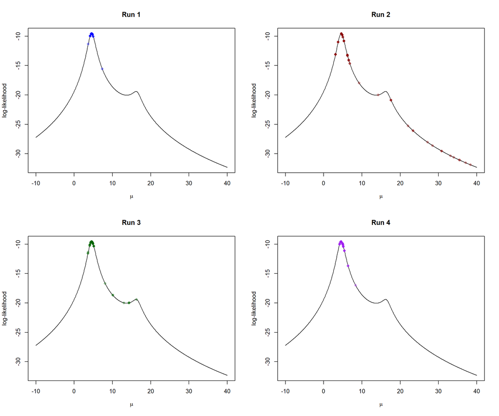

```r
# Create grid for plotting likelihood
mu.x <- seq(-10, 40, length = 1e3)
ll.est <- log(sapply(mu.x, log.like, X))

# Run algorithm 4 times independently
par(mfrow = c(2,2))

colors <- c("blue", "darkred", "darkgreen", "purple")
mles <- numeric(4)

for(i in 1:4){
  sim <- simAn(N = 1e2, r = 5)
  mles[i] <- sim$x[which.max(sim$fn.value)]

  plot(mu.x, ll.est, type = 'l',
       ylab = "log-likelihood",
       xlab = expression(mu),
       main = paste("Run", i))

  points(sim$x, log(sim$fn.value),
         pch = 16,
         col = adjustcolor(colors[i], alpha = .4))
}
```

```r
par(mfrow = c(1,1))

cat("\nMLE estimates from 4 independent runs:\n")
```

```
##
## MLE estimates from 4 independent runs:
```

```r
print(round(mles, 4))
```

```
## [1] 4.5554 4.6508 4.4873 4.5625
```

```r
cat("Mean of estimates:", round(mean(mles), 4), "\n")
```

```
## Mean of estimates: 4.564
```

```r
cat("SD of estimates:", round(sd(mles), 4), "\n")
```

```
## SD of estimates: 0.0671
```

## What This Shows

- **Black curve**: True log-likelihood ℓ(μ)
- **Colored dots**: Sampled parameter values during algorithm execution
- **All 4 plots**: Same likelihood curve but different random trajectories
- **Key observation**: All runs converge to same peak despite different starting points

This demonstrates **global optimization** (not trapped in local maxima).

# Part 6: Effect of Step Size r

## Large Step Size: r = 500

```r
par(mfrow = c(1,2))

# Large r = 500
sim <- simAn(N = 1e3, r = 500)
plot(mu.x, ll.est, type = 'l',
     main = "r = 500. Many rejections",
     ylab = "log-likelihood",
     xlab = expression(mu))
points(sim$x, log(sim$fn.value),
       pch = 16,
       col = adjustcolor("blue", alpha = .2))
cat("\nLarge r = 500:\n")
```

```
##
## Large r = 500:
```

```r
cat("Number of accepted moves:", sum(diff(sim$x) != 0), "out of 999\n")
```

```
## Number of accepted moves: 3 out of 999
```

```r
cat("Acceptance rate:", round(100*sum(diff(sim$x) != 0)/999, 1), "%\n")
```

```
## Acceptance rate: 0.3 %
```

[figure not shown]

**Explanation:** - **r = 500**: Candidates are ±500 from current position - **Problem**: Parameter space is only [-10, 40], so proposals often land far outside data likelihood mass - **Result**: High rejection rate (wasted iterations) - **Trajectory**: Sparse (few accepted moves, many repeated values) - **Efficiency**: Poor

## Small Step Size: r = 0.1

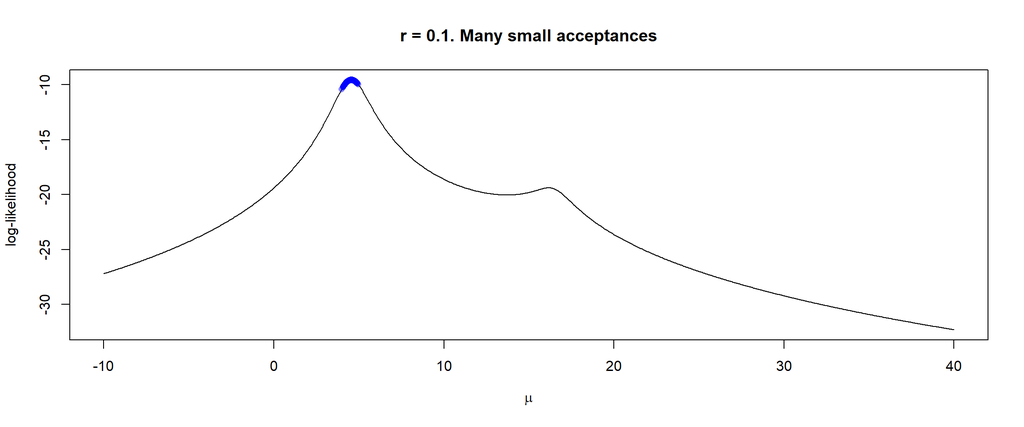

```r
# Small r = 0.1
sim <- simAn(N = 1e3, r = 0.1)
plot(mu.x, ll.est, type = 'l',
     main = "r = 0.1. Many small acceptances",
     ylab = "log-likelihood",
     xlab = expression(mu))
points(sim$x, log(sim$fn.value),
       pch = 16,
       col = adjustcolor("blue", alpha = .2))
```

```r
cat("\nSmall r = 0.1:\n")
```

```
##
## Small r = 0.1:
```

```r
cat("Number of accepted moves:", sum(diff(sim$x) != 0), "out of 999\n")
```

```
## Number of accepted moves: 918 out of 999
```

```r
cat("Acceptance rate:", round(100*sum(diff(sim$x) != 0)/999, 1), "%\n")
```

```
## Acceptance rate: 91.9 %
```

```r
par(mfrow = c(1,1))
```

**Explanation:** - **r = 0.1**: Candidates are ±0.1 from current position - **Advantage**: Nearly all proposals are accepted (high acceptance rate) - **Disadvantage**: Algorithm moves very slowly through parameter space - **Risk**: May not explore broadly enough to find global maximum - **Trajectory**: Dense (many different sampled values)

## Optimal Step Size

**General principle:**
$$r_{opt} \approx \frac{\text{Parameter
Range}}{10}$$

In this case: - Parameter range: [-10, 40] → width = 50 - Optimal r ≈ 5 - This is why r=5 was used in earlier examples

# Summary: Key Concepts

## 1. Temperature Schedule: $T_k = \frac{1}{1 + \ln(\ln(k))}$

- **Decreases over iterations**: Controls landscape shape
- **Early iterations** (high T): Smooth landscape → Broad exploration
- **Late iterations** (low T): Sharp peaks → Local refinement
- **Purpose**: Escape from local maxima early, then converge

## 2. Metropolis Criterion: $\alpha = e^{(\ell(a) - \ell(x_{k-1}))/T}$

- **Always accept** if α > 1 (uphill moves)
- **Probabilistically accept** if α ≤ 1 (downhill moves with probability α)
- **Temperature modulates tolerance**: High T accepts more bad moves
- **Key insight**: Occasional bad moves enable global optimization

## 3. Step Size r

- **Too large**: Rejections dominate, inefficient
- **Too small**: Slow exploration, may miss global maximum
- **Optimal**: r ≈ parameter range / 10
- **Trade-off**: Balance between exploration breadth and acceptance rate

## 4. Convergence Properties

- **Global optimization**: Finds true maximum, not local optimum
- **Robust**: Works from any starting point
- **Multimodal**: Handles non-concave likelihood functions
- **Theoretical guarantee**: With sub-geometric cooling, converges to global optimum as N → ∞

## 5. Why Simulated Annealing Works for Cauchy

- **Problem**: Cauchy likelihood is multimodal (non-concave)
- **Gradient methods fail**: Climb nearest peak, get stuck
- **Simulated Annealing succeeds**: Probabilistically jumps between peaks
- **Cost**: Slower than local methods, but more robust

# Conclusion

Simulated Annealing is a powerful algorithm for **global optimization** that:

1. **Mimics physics**: Models cooling of metals (annealing)
2. **Uses temperature**: Controls exploration vs. exploitation
3. **Employs randomness**: Escapes local optima probabilistically
4. **Guarantees convergence**: Under mild conditions, finds global optimum
5. **Applies broadly**: Works for any multimodal optimization problem

The algorithm is particularly valuable for: - Maximum likelihood estimation in complex models - Parameter inference with non-concave likelihood - Any discrete or continuous optimization problem - Problems where gradients are unavailable or unreliable

# References

- Metropolis, N., Rosenbluth, A. W., Rosenbluth, M. N., Teller, A. H., & Teller, E. (1953). Equation of state calculations by fast computing machines. Journal of Chemical Physics.
- Kirkpatrick, S., Gelatt, C. D., & Vecchi, M. P. (1983). Optimization by simulated annealing. Science, 220(4598), 671-680.